# Conventions for handling negative response values: simulation results

## The study

We simulated concentration-response data from a four-parameter curve (`nec4param`) in which specific growth rate falls from a positive control value to a negative lower asymptote, and we handed each simulated dataset to six analyses that differ only in how they treat the negative values. Every analysis uses `bayesnec` with package defaults, model-averaged over the declining candidate set the family allows, so a difference between arms is the difference a practitioner would obtain rather than a likelihood-only contrast.

**Table 1.** The six conventions compared. All six are reachable from `bnec()` defaults.

| arm | what the analyst does | family |
| --- | --- | --- |
| measured | use the values as recorded | gaussian |
| censored | declare negatives left-censored at zero | gaussian |
| deleted | delete the negative rows, keep the rest of their group | gaussian |
| floored | replace negatives with zero | gaussian |
| beta | floor, scale to (0, 1), fit a Beta | Beta |
| gamma | floor, fit a Gamma | Gamma |

Seven design cells were run, each 100 times. Four vary measurement precision alone, holding the design and the true values fixed, so that the control coefficient of variation falls from 9.6% to 1.9%. Two vary the depth of the lower asymptote. One stops the concentration series at the point where the true curve reaches zero growth, so that almost nothing is negative and the conventions have nothing to act on.

The true values are known by construction, so each analysis is scored against them rather than against each other. We report relative bias, the proportion of 95% credible intervals containing the truth, and the mean interval width.

Four real datasets are analysed by the same six conventions as well. They have no known truth, so they are not scored; what they show is how far the choice changes the number that would be reported on data nobody simulated.

Everything here comes from one pinned commit of `bayesnec`, and the results it replaces came from another. The Provenance section says which, and what changed between them.

## Estimating ErC50

The concentration halving the growth rate separates the conventions cleanly, and it separates them by whether the measurement is kept.

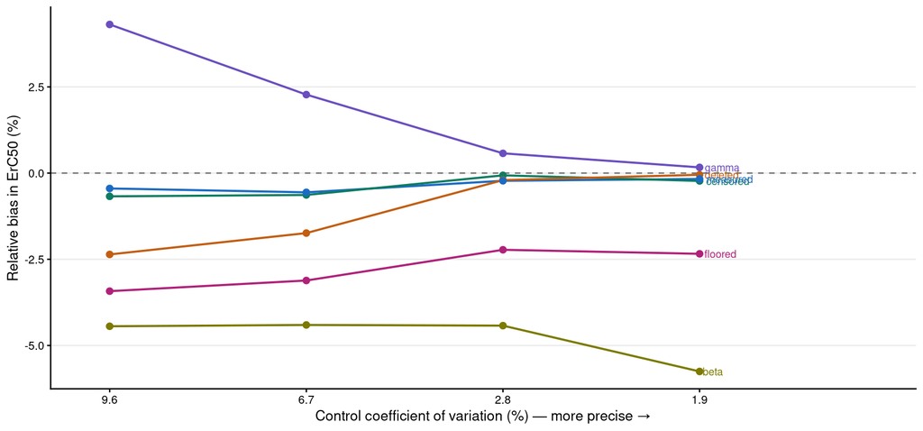

Figure 1

**Figure 1.** Relative bias in the estimated ErC50 against measurement precision, 100 simulated datasets per point. Arms that keep the measurement converge on the true value; arms that replace it level off away from zero.

## Estimating ErC10

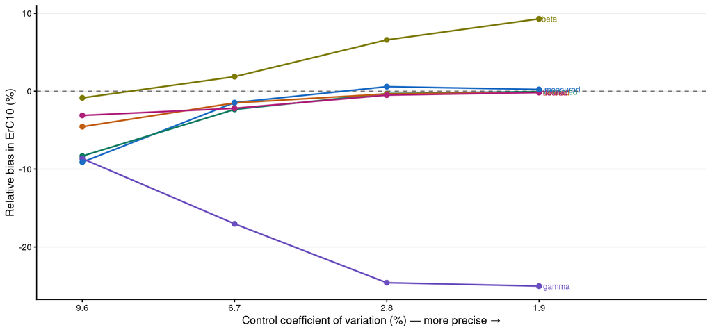

Figure 2

ErC10 is the harder estimate for every arm at realistic noise, because a 10% decline from the control has to be resolved against a control coefficient of variation of 9.6%. That is a property of the endpoint rather than of any convention, and it is why the precision axis is necessary to interpret it.

## The NSEC

The no-significant-effect concentration is where the conventions diverge most, and where they diverge in a direction that matters for protection.

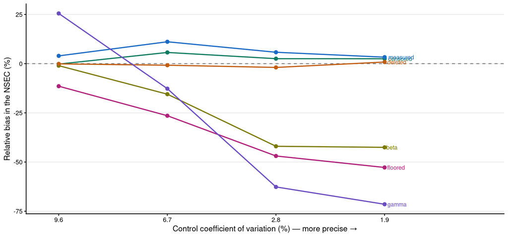

Figure 3

**Figure 3.** Relative bias in the estimated NSEC against the true no-effect concentration. The three arms that keep the measurement converge toward it from above; the three that replace it diverge downward as precision improves.

The NSEC’s expected value exceeds the true `nec` at any finite level of noise, because it is defined against a lower quantile of the control posterior: a noisier control gives a lower reference and pushes the crossing to the right. Its limiting value as the residual error goes to zero is the true `nec`, which is why the precision axis is the only way to read it.

## Interval coverage

Bias understates the problem, because the intervals narrow around a displaced centre as the experiment improves.

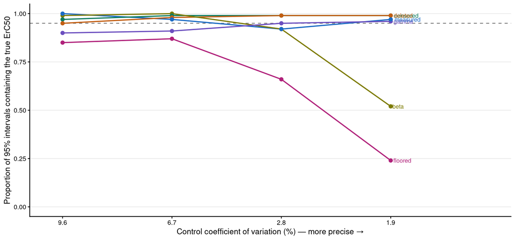

Figure 4

**Table 2.** ErC50 at the two ends of the precision axis. Coverage and interval width are reported together, because either alone identifies the wrong arm as the best one.

| cell | arm | bias (%) | coverage | mean width | RMSE |
| --- | --- | --- | --- | --- | --- |
| CV 1.9% | measured | -0.17 | 0.97 | 0.135 | 0.032 |
| CV 1.9% | censored | -0.23 | 0.99 | 0.269 | 0.061 |
| CV 1.9% | deleted | -0.05 | 0.99 | 0.300 | 0.076 |
| CV 1.9% | floored | -2.34 | 0.24 | 0.198 | 0.124 |
| CV 1.9% | beta | -5.75 | 0.52 | 0.558 | 0.295 |
| CV 1.9% | gamma | 0.17 | 0.96 | 0.288 | 0.087 |
| CV 9.6% | measured | -0.45 | 1.00 | 0.861 | 0.170 |
| CV 9.6% | censored | -0.67 | 0.97 | 0.924 | 0.204 |
| CV 9.6% | deleted | -2.36 | 0.95 | 0.997 | 0.265 |
| CV 9.6% | floored | -3.42 | 0.85 | 0.884 | 0.292 |
| CV 9.6% | beta | -4.44 | 0.99 | 1.557 | 0.315 |
| CV 9.6% | gamma | 4.31 | 0.90 | 2.338 | 0.414 |

A laboratory that improves its technique, adds replicates and reduces its control variability will, if it replaces its negative values, obtain an analysis that is more confident and no more accurate.

## Where the response barely goes negative

**Table 3.** The control cell, in which the concentration series stops where the true curve reaches zero growth, so that almost no true mean is negative.

| estimate | arm | bias (%) | coverage |
| --- | --- | --- | --- |
| ErC50 | measured | -0.66 | 0.99 |
| ErC50 | censored | -0.78 | 0.99 |
| ErC50 | deleted | -0.42 | 0.97 |
| ErC50 | floored | -0.54 | 0.98 |
| ErC50 | beta | -0.68 | 1.00 |
| ErC50 | gamma | 0.93 | 0.98 |
| NSEC | measured | 1.08 | 0.98 |
| NSEC | censored | 1.42 | 0.98 |
| NSEC | deleted | 1.10 | 0.99 |
| NSEC | floored | 0.45 | 0.98 |
| NSEC | beta | -6.63 | 1.00 |
| NSEC | gamma | 90.30 | 0.96 |

Where the design does not reach the zero-growth boundary, the four Gaussian arms agree to within about two per cent on ErC50 and the conventions have nothing to act on. The two family-imposed arms still differ, because scaling to a proportion or fitting a Gamma changes the analysis whether or not any value is negative.

This is the condition under which none of the results above apply. Reporting the proportion of observations at or below zero is what tells a reader which situation they are in.

## Convergence, read against model weight

Every fit records `rhat` and the tail effective sample size for the curve parameters of each equation in its candidate set, beside the stacking weight that equation holds. The two are only readable together. An equation whose shape suits the data badly fails a diagnostic whatever the data are doing, and is given almost no weight for the same reason, so a failure on a near-zero-weight equation describes that curve rather than the model-averaged estimate.

**Table 4.** Mean stacking weight held by equations that fail a convergence diagnostic, by cell and arm, over the realisations of that cell. Twelve worst shown. A row near zero means the diagnostics that failed were on equations the average barely used.

| cell | arm | weight on rhat > 1.01 | weight on tail ESS < 400 |
| --- | --- | --- | --- |
| ctl | gamma | 0.005 | 0.052 |
| d8 | gamma | 0.002 | 0.014 |
| p1 | gamma | 0.005 | 0.009 |
| ctl | deleted | 0.001 | 0.012 |
| d8 | beta | 0.000 | 0.008 |
| p1 | measured | 0.002 | 0.006 |
| d2 | gamma | 0.001 | 0.006 |
| d2 | measured | 0.000 | 0.006 |
| p2 | gamma | 0.001 | 0.005 |
| ctl | floored | 0.001 | 0.005 |
| d8 | deleted | 0.002 | 0.004 |
| p2 | censored | 0.003 | 0.002 |

The previous run of this study recorded no diagnostics at all, so when the question arose of whether a badly mixing equation had affected an estimate there was nothing on disk to answer it with. That is why they are collected here.

## The case studies

Four marine microalgal growth tests were analysed by the same six conventions, from the `alga` data that ship with `bayesnec`: two tests on *Cladocopium proliferum* over seven days and two on *Rhodomonas salina* over three, each species against two contaminants on undisclosed and mutually incomparable concentration scales.

They are run here rather than when the vignette is built. Four datasets by six conventions, each averaged over thirteen or fourteen equations, is a fifteen-hour build, which is not something to run on a workstation whenever a sentence changes. What that costs is stated rather than hidden: the case-study estimates no longer track whatever version of `bayesnec` they are published beside. They report the commit named in `hpc/bayesnec.lock`, exactly as the simulation does.

The two *Rhodomonas* tests need one qualification before their results are read. At the highest concentrations the population fell below the counting limit of 10 cells per mL, so the growth rate is undefined rather than negative. Every convention must therefore substitute something there, including the ones that otherwise retain the measurement, and on those two datasets no convention is a true analysis of what was measured. Censoring is the exception in kind rather than in degree: it can state that the value lies at or below the rate the counting limit implies without inventing one.

**Table 5.** ErC50 from each convention on each dataset, with the equation the average leaned on most and the combined weight on the six equations whose lower asymptote is fixed at zero. There is no truth to score these against; what they show is how far the choice of convention changes the number that would be reported.

| dataset | arm | ErC50 | lower | upper | highest-weighted | its weight | weight on zero-asymptote |
| --- | --- | --- | --- | --- | --- | --- | --- |
| c_proliferum | measured | 9.413 | 8.255 | 9.975 | ecxwb1 | 0.49 | 0.00 |
| c_proliferum | censored | 6.818 | 6.233 | 7.452 | neclin | 0.46 | 0.00 |
| c_proliferum | deleted | 6.944 | 6.218 | 7.657 | nec3param | 0.33 | 0.50 |
| c_proliferum | floored | 6.795 | 6.081 | 7.428 | ecxsigm | 0.28 | 0.61 |
| c_proliferum | beta | 6.863 | 5.820 | 7.543 | ecxwb1 | 0.59 | 0.05 |
| c_proliferum | gamma | 7.229 | 5.263 | 8.917 | ecxwb1 | 0.51 | 0.19 |
| c_proliferum2 | measured | 368.359 | 354.355 | 380.997 | ecxwb2 | 0.86 | 0.00 |
| c_proliferum2 | censored | 356.748 | 343.317 | 370.329 | neclin | 0.50 | 0.00 |
| c_proliferum2 | deleted | 355.459 | 340.334 | 369.277 | neclin | 0.33 | 0.41 |
| c_proliferum2 | floored | 356.563 | 343.761 | 369.150 | ecxsigm | 0.49 | 0.74 |
| c_proliferum2 | beta | 353.769 | 328.204 | 375.942 | ecx4param | 0.27 | 0.01 |
| c_proliferum2 | gamma | 362.864 | 355.242 | 370.448 | ecxwb1 | 1.00 | 0.00 |
| r_salina | measured | 5.067 | 5.011 | 5.172 | ecxwb1 | 0.42 | 0.00 |
| r_salina | censored | 5.126 | 5.019 | 5.202 | ecxwb1 | 0.38 | 0.00 |
| r_salina | deleted | 4.993 | 4.980 | 4.997 | ecxsigm | 0.18 | 0.43 |
| r_salina | floored | 5.169 | 5.041 | 5.253 | ecxwb1p3 | 0.50 | 0.64 |
| r_salina | beta | 5.162 | 5.002 | 5.381 | ecxwb1 | 0.84 | 0.00 |
| r_salina | gamma | 5.159 | 5.019 | 5.222 | ecxwb1 | 0.87 | 0.00 |
| r_salina2 | measured | 123.768 | 110.917 | 141.186 | nec4param | 0.89 | 0.00 |
| r_salina2 | censored | 116.096 | 108.423 | 123.366 | nec4param | 0.89 | 0.00 |
| r_salina2 | deleted | 109.059 | 103.000 | 116.006 | ecxwb2p3 | 0.20 | 0.60 |
| r_salina2 | floored | 109.808 | 105.108 | 116.077 | ecxwb2p3 | 0.19 | 0.44 |
| r_salina2 | beta | 109.117 | 102.615 | 117.519 | ecxwb2 | 0.43 | 0.00 |
| r_salina2 | gamma | 107.937 | 87.350 | 120.016 | ecxwb1 | 0.32 | 0.00 |

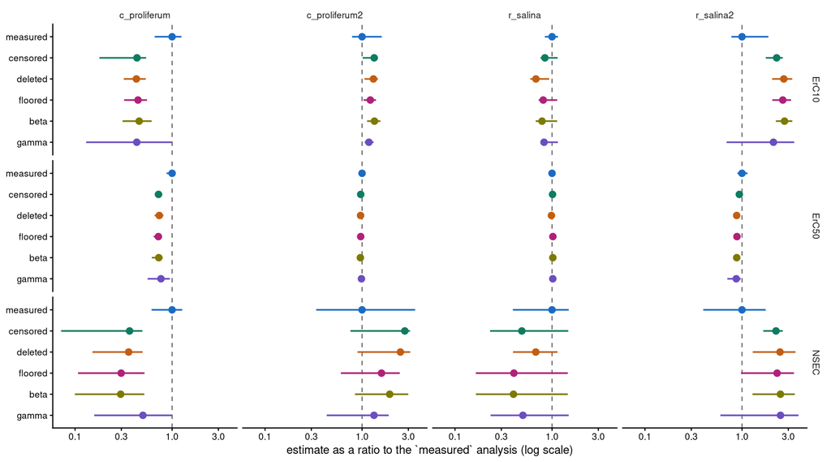

Figure 5

## What the study establishes

The measurement should be kept. Across the precision axis `measured` recovers the true ErC50 to within 0.6%, and at the highest precision tested its interval contains the truth in 0.97 of realisations.

Where the negative values were never recorded, censoring recovers almost all of what replacing them loses: at the highest precision `censored` reports an ErC50 bias of -0.2% against -0.2% for the measurements themselves.

Deleting the negative rows is better than replacing them with zero and worse than either alternative above. It discards information that censoring retains, and it changes the replication per concentration rather than the values, which at the top of a series can remove a treatment group altogether.

Replacing negative values with zero leaves an ErC50 bias of -2.3% at the highest precision that does not shrink as the experiment improves, so interval coverage falls to 0.24, and it displaces the NSEC by -52.8%.

Imposing the boundary through the response distribution is the same practice reached by a different route and performs no better. `beta` holds an ErC50 bias of -5.8% at the highest precision; `gamma` is close to unbiased on ErC50 and displaces ErC10 by -25.0%, with coverage of 0.01, so the two estimates cannot be summarised together for that convention.

Where the design does not reach the zero-growth boundary none of this applies: in the `ctl` cell the four Gaussian conventions span 0.4 percentage points of ErC50 bias between them, against 3.0 in `p1`, which has the same control variability and four times as many negative observations.

## Provenance

The study is 4,200 model-averaged fits for the simulation — seven cells, six conventions, 100 realisations — and 24 for the case studies, each fit averaging over the declining candidate set its family allows. It ran on the AIMS HPC as SLURM arrays, one unit per task.

`bayesnec` is pinned at the commit named in `hpc/bayesnec.lock`, on the `dev` branch. That is a development commit rather than a CRAN release, and the difference matters here more than it usually would, because what this study measures is what package defaults do.

This is a re-run. The previous results, produced at `0976caca`, are kept under `archive/bayesnec-0976caca/` and cannot be pooled with these. Three changes between the two alter every fit:

- the `nec` and `ec50` priors are now built on the log of the predictor, so their central 95% interval covers the concentrations tested rather than a fraction of them. On the reference cell the `nec` prior went from `gamma(5, 2.666)` to `lognormal(0.615, 1.175)`, which moves the true ErC50 from above the 99th percentile of its own prior to the 80th;
- the regularizing prior set was redefined and anchored on the predictor. This study uses the default `uninformative` set, so that changes nothing here directly and is named because it is part of the same release;
- the initial-value search was rewritten to accept chains individually and to band the curve on level means, which changes the starting values of every fit.

The container holds the toolchain and not the package: it is the image built by the `bayesnec` repository for precompiling its vignettes, and the job installs `bayesnec` from the pinned source at start-up. `hpc/image.lock` records which image produced these results and every job refuses to run against one whose SHA does not match it. Rebuilding the image is a change that can alter published numbers, so it is made deliberately rather than discovered afterwards.

The simulation’s priors are held fixed within a cell and arm rather than derived from each realisation. `bayesnec` derives its defaults from the response vector and `brms` writes them into the Stan source as literals, so a prior that varies by realisation makes every fit a distinct Stan program: 5,622 compiles for 406 units before this was changed. Fixing them makes the program identical across iterations. Each arm keeps its own prior, derived from its own prepared data, so the contrast between arms is unaffected, and the exact values used are committed as 42 files in `priors/`.

The case studies take `bnec()`’s own defaults instead. Each dataset and arm is fitted once, so there is no repetition for an identical program to save, and taking the defaults is the practice they exist to show.

The generating model is carried over verbatim from open-AIMS/negative-sgr at commit `0181d66e`. Nothing else is.

**Table 6.** What produced these numbers, read from the two lock files rather than typed.

| item | value |
| --- | --- |
| bayesnec commit | 25466e53d420b809b4b18794228729d2265c595f |
| bayesnec version | 2.1.3.33 |
| branch | dev |
| base image | rocker/r-ver:4.6.1 |
| R | 4.6.1 |
| cmdstan | 2.39.0 |
| CRAN snapshot | https://p3m.dev/cran/**linux**/noble/2026-09-10 |
| image sha256 | 1202e1dd7eed40cc |